# Test1

## MATH2350 - Introduction to Analytics

### In-Semester Test 1

### Semester 2, 2019

###### **Integrity Statement**

- I hereby agree to follow any and all in-semester test rules and procedures as stated in the Assessments Info page on Canvas for this course.
- I solemnly declare that I will not communicate/ have not communicated with anyone in any way (other than the test invigilators) during the test (such as via emails, texting, chats, sharing files on Dropbox, etc).

Please type your full legal name in the box below as your signature per your acceptance of the Integrity Statement. **Your test shall not be marked if you do not sign.**

Full Name: Chentao Xu

##### **Test Instructions**

- For each test question, feel free to add more Markdown/ Code answer cells as needed, but please keep these additions to a minimum.
- Please keep your answers neatly organised. You will lose points if your solutions are all over the place.
- You must show all your work for full credit.
- Once you are done, it is your responsibility to compile (run) your notebook and then save it as an HTML file before submission. Your solutions shall be marked exactly as they appear in your HTML file.
- You can submit your solutions file via *Canvas > Assignments > In-Semester Test 1*.
- You must submit your solutions before the due time. If you miss the due time, you will receive a mark of zero for the test.
- This test contains 6 questions for a total of 100 points.

```python
# common statements
import pandas as pd
import numpy as np
import matplotlib.pyplot as plt
%matplotlib inline
%config InlineBackend.figure_format = 'retina'
plt.style.use("ggplot")
```

**QUESTION 1: (10 points)** Identify the following random variables as **discrete** or **continuous**. You do **not** need to explain your reasoning.

**A. (2 points)** Length of a Python string object.

discrete

**B. (2 points)** Execution time of a Python program.

continuous

**C. (2 points)** Average satisfaction rate in a course survey with a large number of students.

continuous

**D. (2 points)** Number of rows in a Pandas DataFrame object.

discrete

**E. (2 points)** Score in a test with all multiple choice questions (MCQs).

discrete

**QUESTION 2: (10 points)** A statistics course offered at RMIT has 250 students. All these students attend the lectures together, but the students are divided into 5 groups, each of 50 students, for tutorial sections administered by different tutors. The lecturer wants to conduct a survey about how satisfied the students are with the course, and he believes that the tutorial section a student is in might affect the student's overall satisfaction with the course.

**A. (2 points)** What type of study is this?

**B. (4 points)** Suggest a sampling strategy for carrying out this study.

Stratified sample can be used to carry out this tudy. This is because the study population has already been divided into 5 strata, each of 50 students. A simple random sample can be taken from each stratum where study can be carried out.

**C. (4 points)** Consider RMIT's CES (Course Evaluation Survey) in general that you are asked to complete for each course at the end of each semester. What types of sampling biases are there in CES? Please just list the biases - no explanation is needed.

Non response, voluntary response

**QUESTION 3: (15 points)** For each of the following, state whether

- you expect the distribution to be symmetric, right skewed, or left skewed.
- the mean or median would best represent a typical observation in the data, and
- the variability of observations would be best represented using the standard deviation or IQR.

You do **not** need to explain your reasoning.

**A. (5 points):** Number of laptops in a household.

- right skewed.
- mean
- IQR

**B. (5 points):** House prices

- left skewed
- median
- IQR

**C. (5 points):** Weights of people

- symmetric
- median
- IQR

**QUESTION 4: (15 points)** (fictitious) A cancer institute published the results of a study that investigated the association between smoking and death from lung cancer. Data were obtained for a national sample of almost 120,000 deceased people. The results are summarized in the table below. Each subject in the study was classified according to their smoking status and whether or not they died from lung cancer.

| Died From Lung Cancer? ->> | *YES* | *NO* | Total |
| --- | --- | --- | --- |
| Never Smoked | 75 | 98,121 | 98,196 |
| Former Smoker | 680 | 8,345 | 9,025 |
| Current Smoker | 768 | 11,321 | 12,089 |
| **Total** | 1,523 | 117,787 | 119,310 |

**A. (5 points)** Find the probability that a randomly selected person never smoked and died from lung cancer.

**B. (10 points)** Given that a person died from lung cancer, what is the probability that this person smoked at some point in his/her life (that is, either a former smoker or a current smoker)?

**QUESTION 5: (15 points)** (fictitious) A journal published a study on the gender of children in two-child families. The article reported on the results of the Global Health Issues Interview Survey of almost 50,000 two-child families. The table gives the proportion of families with each gender configuration.

| Gender Configuration | Proportion |
| --- | --- |
| Boy-boy (BB) | 0.235 |
| Girl-boy (GB) | 0.262 |
| Boy-girl (BG) | 0.251 |
| Girl-girl (GG) | 0.252 |

Let the random variable X represent the number of girls in a two-child family.

**A. (6 points)** Find the probability distribution for X.

X=0, X=1, X=2

**B. (6 points)** Find the expected value for X.

**C. (3 points)** Provide a real-world interpretation for the expected value you found in Part (B).

**QUESTION 6: (35 points) (Infant Mortality)** The infant mortality rate is defined as the number of child deaths under one year of age, expressed per 1000 live births. Under the Test 1 page on Canvas, you will see a CSV file named "oecd_inf_mortality.csv". This file contains infant mortality data for OECD countries between the years of 1960 and 2017. You will read in this dataset as a Pandas DataFrame object called "df".

**A. (5 points)** How many rows and columns are there in this dataset? Also display 10 randomly selected rows.

```python
cdc = pd.read_csv('oecd_inf_mortality.csv')

# Convert the dictionary into DataFrame
df = pd.DataFrame(cdc)

print(df.shape)
print(df.head(10))
```

```
(2002, 3)
  country  year  inf_mortality
0     AUS  1960           20.2
1     AUT  1960           37.5
2     BEL  1960           31.4
3     CAN  1960           27.3
4     CZE  1960           20.0
5     DNK  1960           21.5
6     FIN  1960           21.0
7     FRA  1960           27.7
8     DEU  1960           33.8
9     GRC  1960           40.1
```

**B. (5 points)** How many countries are included in this dataset?

```python
print(df[ 'country' ].count)
```

[output not shown]

[output cut: 47 more lines]

**C. (3 points)** Subset this dataset for the year 2015 and assign it to a Pandas DataFrame object called "df2015". In the rest of this question, you will only be working with the `df2015` data frame. How many rows are there in this data frame?

```python
df2015 = df
print(df2015.shape)
```

```
(2002, 3)
```

**D. (7 points)** Generate an histogram of infant mortality rates for the year of 2015 with 10 bins. Comment on the skewness and modality of this histogram.

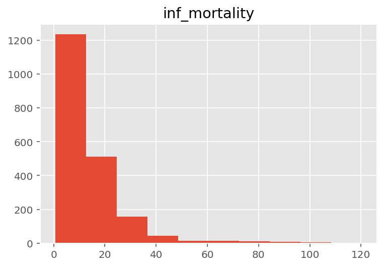

```python
df2015.hist(column=[ 'inf_mortality' ]);
```

This histogram right-skewed, where its mode is at 0-10.

**E. (6 points)** Compute a 5-number summary for infant mortality for the year of 2015. Also compute the IQR.

```python
df2015.sort_values(by='inf_mortality', ascending = False).head(5)
```

|  | country | year | inf_mortality |
| --- | --- | --- | --- |
| 28 | CHL | 1960 | 120.3 |
| 61 | CHL | 1961 | 108.9 |
| 94 | CHL | 1962 | 108.0 |
| 160 | CHL | 1964 | 102.9 |
| 127 | CHL | 1963 | 100.2 |

**F. (9 points)** Generate a boxplot for the same dataset in Part (E). How many outliers do you see? Find out which countries these are using the max whisker reach value.

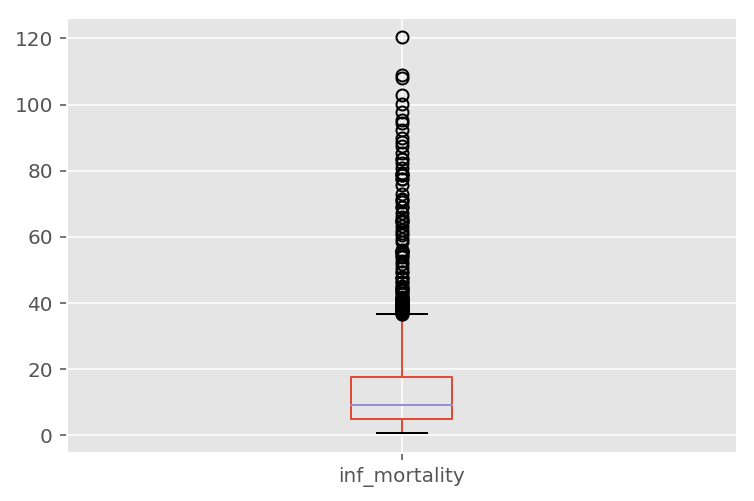

```python
df2015.boxplot(column=['inf_mortality']);
```

**------------------------------ END OF TEST ------------------------------**